# 291024test

### Упражнение 6: Оценка процента дефектных изделий на производстве

Вы работаете на производственной линии компании, которая производит электронные компоненты. Ваша задача - оценить процент дефектных изделий, производимых на линии. Вы верите, что истинный процент дефектных изделий составляет 5% (p = 0.05), но вы хотите это проверить на основе выборки.

Для этой задачи вы случайным образом выбрали 100 изделий с производственной линии и проверили каждое из них на наличие дефектов. В результате, вы получили данные:

```r
# 94 изделий были без дефектов (успех)
# 6 изделий были дефектными (неудача)
# Ваша задача: Проверить гипотезу о том, что процент дефектных изделий действительно равен 5% (p = 0.05) на основе данных выборки.

# Задача о доле признаков

n<-100
fail<-6
p_est<-fail/n

p_hyp<-0.05
# H0: p = 0.05 (Доля деф.изделий соответствует ожиданиям)
# H1: p != 0.05 (Доля деф.изделий не соответствует ожиданиям)
res<-prop.test(fail, n, p_hyp)

# p-value = 0.8185

# p-value > 0.05 - не отвергаем H0 (доля деф.изделий соответствует ожиданиям)
```

+++++++++++++++++++++++++++++++++++++++++++++++++++++++++ +++++++++++++++++++++++++++++++++++++++++++++++++++++++++ ### Упражнение 7: Оценка нормальности распределения результатов испытаний

Вы работаете в лаборатории, где проводятся испытания материалов на прочность. Вашей задачей является определение, насколько результаты этих испытаний соответствуют нормальному распределению. Вы собрали данные о прочности материалов и хотите провести статистический тест, чтобы определить, является ли распределение результатов нормальным.

Здесь alpha = 0.10, чтобы уменьшить ошибку второго рода и, тем самым, увеличить мощность критерия и точнее разделять H0 и H1.

```r
# Для этой задачи, давайте предположим, что у вас есть выборка из 100 результатов испытаний на прочность материалов. Вы представили данные в виде вектора в R:

strength_data <- c(82.5, 78.9, 85.2, 88.1, 91.6, 87.5, 89.3, 80.7, 84.6, 86.8,
                   81.2, 83.7, 90.5, 85.9, 92.3, 87.2, 84.6, 86.8, 89.4, 91.0,
                   79.3, 85.7, 88.2, 83.6, 82.1, 84.8, 86.2, 87.9, 85.3, 81.7,
                   88.9, 84.5, 85.8, 90.7, 86.1, 83.4, 88.7, 84.8, 87.2, 89.1,
                   91.4, 82.7, 85.3, 87.8, 80.4, 83.9, 88.5, 90.2, 85.7, 86.9,
                   89.6, 82.3, 86.8, 83.6, 87.4, 84.5, 88.0, 90.1, 85.6, 86.3,
                   89.0, 83.1, 87.2, 85.8, 88.3, 84.9, 89.5, 86.7, 83.2, 88.8,
                   85.1, 89.3, 87.1, 84.2, 86.0, 88.2, 85.5, 86.8, 83.8, 88.4,
                   85.0, 89.1, 87.3, 84.0, 86.5, 88.6, 85.4, 87.0, 89.2, 86.6,
                   84.3, 88.1, 85.9, 89.4, 86.4, 84.4, 88.3, 85.2, 89.5, 86.3)

# Для проверки распределения на соответствие нормальному распределению воспользуемся
# критерием Шапиро-Уилка (Shapiro-Wilk normality test)

# H0: Результаты соответствуют норм.распределению
# H1: Результаты не соответствуют норм.распределению
library(ggpubr)
```

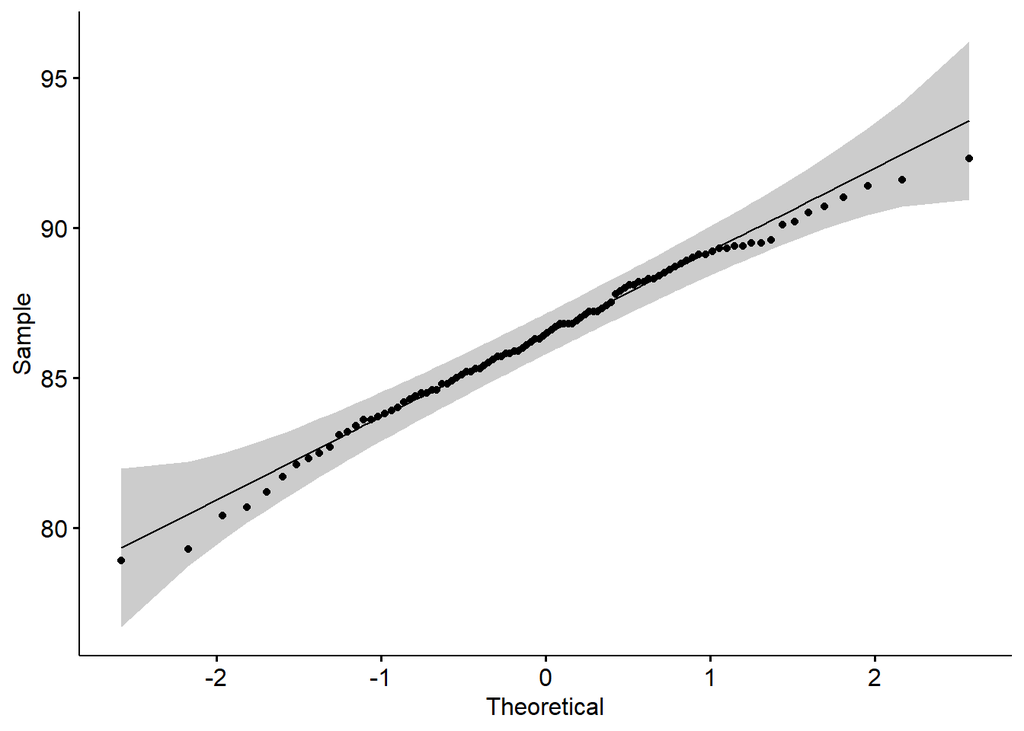

```r
result<-list(qqplot=ggqqplot(strength_data), shapiro_wilk=shapiro.test(strength_data))
result$qqplot
```

```r
result$shapiro_wilk
```

```
##
##  Shapiro-Wilk normality test
##
## data:  strength_data
## W = 0.98918, p-value = 0.5988
```

```r
result$shapiro_wilk$p.value
```

```
## [1] 0.5988334
```

```r
# p-value > 0.10 - не отвергаем H0 (результаты соответствуют нормальному распределению)
```

+++++++++++++++++++++++++++++++++++++++++++++++++++++++++ +++++++++++++++++++++++++++++++++++++++++++++++++++++++++